# Air Quality and Asthma Emergency Department Visits in New York City

Sabina Baraili

2025-12-14

# 1. Motivation and Research Question

Asthma is a major public health concern in New York City, with emergency department (ED) visit rates varying considerably across neighborhoods. Environmental exposure, particularly to fine particulate matter (PM2.5), has been linked in prior research to adverse respiratory outcomes. However, exposure to air pollution is not evenly distributed across communities.

This project examines whether neighborhoods with higher PM2.5 concentrations also experience higher asthma-related emergency department visit rates. Understanding this relationship can help identify environmental health disparities and inform public health interventions.

**Research Question:**  
Is neighborhood-level PM2.5 concentration associated with asthma emergency department visit rates in New York City?

# 2. Data Sources

Two official datasets from the NYC Department of Health and Mental Hygiene Environmental Health Data Portal are used:

1. **Asthma Emergency Department Visits (Adults)**  
   Age-adjusted asthma ED visit rates per 10,000 adults by community district.
2. **Fine Particulate Matter (PM2.5)**  
   Annual mean PM2.5 concentrations (µg/m³) by community district.

```r
asthma_raw <- read_csv(
  "NYC EH Data Portal - Asthma emergency department visits (adults) (full table).csv"
) |> clean_names()

pm25_raw <- read_csv(
  "NYC EH Data Portal - Fine particles (PM 2.5) (full table).csv"
) |> clean_names()
```

# 3. Data Cleaning and Transformation

```r
asthma_clean <- asthma_raw |>
  filter(geo_type == "CD") |>
  select(
    time_period,
    geography,
    asthma_rate = age_adjusted_rate_per_10_000
  ) |>
  mutate(asthma_rate = as.numeric(asthma_rate))

pm25_clean <- pm25_raw |>
  filter(geo_type == "CD") |>
  select(
    time_period,
    geography,
    pm25 = annual_mean_mcg_m3
  ) |>
  mutate(pm25 = as.numeric(pm25))

nyc_health <- inner_join(
  asthma_clean,
  pm25_clean,
  by = c("time_period", "geography")
) |>
  drop_na()
```

# 4. Exploratory Data Analysis

## 4.1 Distribution of Asthma ED Visit Rates

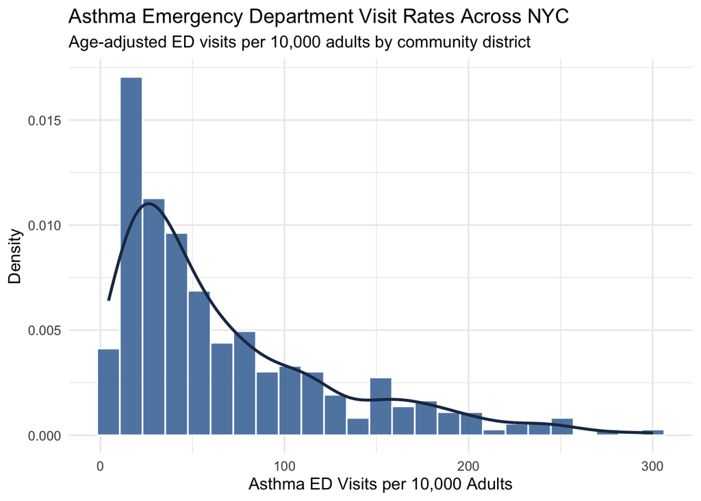

```r
ggplot(nyc_health, aes(x = asthma_rate)) +
  geom_histogram(
    aes(y = after_stat(density)),
    bins = 25,
    fill = "#4C78A8",
    color = "white",
    alpha = 0.9
  ) +
  geom_density(color = "#1F3552", linewidth = 1) +
  labs(
    title = "Asthma Emergency Department Visit Rates Across NYC",
    subtitle = "Age-adjusted ED visits per 10,000 adults by community district",
    x = "Asthma ED Visits per 10,000 Adults",
    y = "Density"
  ) +
  theme_minimal(base_size = 12)
```

## 4.2 Distribution of PM2.5 Concentrations

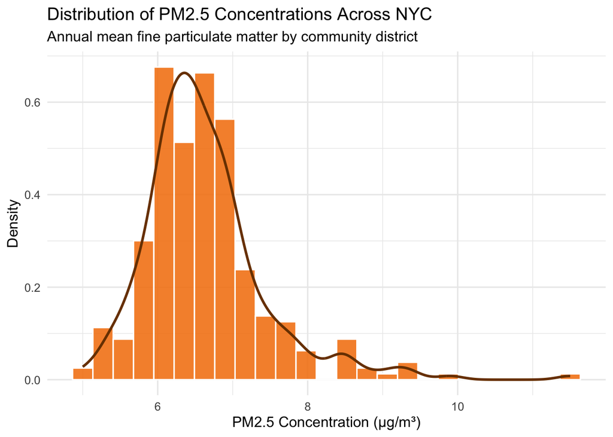

```r
ggplot(nyc_health, aes(x = pm25)) +
  geom_histogram(
    aes(y = after_stat(density)),
    bins = 25,
    fill = "#F58518",
    color = "white",
    alpha = 0.9
  ) +
  geom_density(color = "#7A3E00", linewidth = 1) +
  labs(
    title = "Distribution of PM2.5 Concentrations Across NYC",
    subtitle = "Annual mean fine particulate matter by community district",
    x = "PM2.5 Concentration (µg/m³)",
    y = "Density"
  ) +
  theme_minimal(base_size = 12)
```

# 5. Statistical Analysis

## 5.1 Correlation Analysis

```r
cor.test(nyc_health$pm25, nyc_health$asthma_rate)
```

```
##
##  Pearson's product-moment correlation
##
## data:  nyc_health$pm25 and nyc_health$asthma_rate
## t = -0.43673, df = 293, p-value = 0.6626
## alternative hypothesis: true correlation is not equal to 0
## 95 percent confidence interval:
##  -0.13929808  0.08895102
## sample estimates:
##         cor
## -0.02550595
```

## 5.2 Linear Regression

```r
model <- lm(asthma_rate ~ pm25, data = nyc_health)
summary(model)
```

```
##
## Call:
## lm(formula = asthma_rate ~ pm25, data = nyc_health)
##
## Residuals:
##    Min     1Q Median     3Q    Max
## -64.12 -44.13 -21.76  26.40 234.84
##
## Coefficients:
##             Estimate Std. Error t value Pr(>|t|)
## (Intercept)    79.68      28.45   2.801  0.00544 **
## pm25           -1.86       4.26  -0.437  0.66263
## ---
## Signif. codes:  0 '***' 0.001 '**' 0.01 '*' 0.05 '.' 0.1 ' ' 1
##
## Residual standard error: 59.72 on 293 degrees of freedom
## Multiple R-squared:  0.0006506,  Adjusted R-squared:  -0.00276
## F-statistic: 0.1907 on 1 and 293 DF,  p-value: 0.6626
```

```r
tidy(model)
```

```
## # A tibble: 2 × 5
##   term        estimate std.error statistic p.value
##   <chr>          <dbl>     <dbl>     <dbl>   <dbl>
## 1 (Intercept)    79.7      28.4      2.80  0.00544
## 2 pm25           -1.86      4.26    -0.437 0.663
```